# Beta

Marisangila Alves

10/26/2021

### Parâmetros

```
      Parâmetros      | Valores
----------------------|----------
alfa zipf             | 0.8
lambda                | 5
n                     | 100
beta                  | 0.1, 0.2, 0.3, 0.4, 0.5
BS                    | 32
Cache                 | 100
UE                    | 200
Storage               | MBS 20GB SBS 4GB
Coverage              | MBS 300 SBS 70
RTT inicial           | CS/MBS 0.001s(1ms) MBS/MBS 0.001s(1ms) MBS/SBS 0.001s(1ms) SBS/UE 0.001s(1ms)
Tempo da Requisição   | 10 eventos
Mobilidade            | 40m
```

### Informações da Aplicação.

```
  Vazão Mínima |     Tamanho da Cache        | Buffer |
---------------|-----------------------------|--------|
   100 Mbps    |      2GB/2000MB             |  48Mb  |
   100 Mbps    |      4GB/4000MB             |  48Mb  |
   100 Mbps    |      8GB/8000MB             |  48Mb  |
```

### Tempo de execução da otimização.

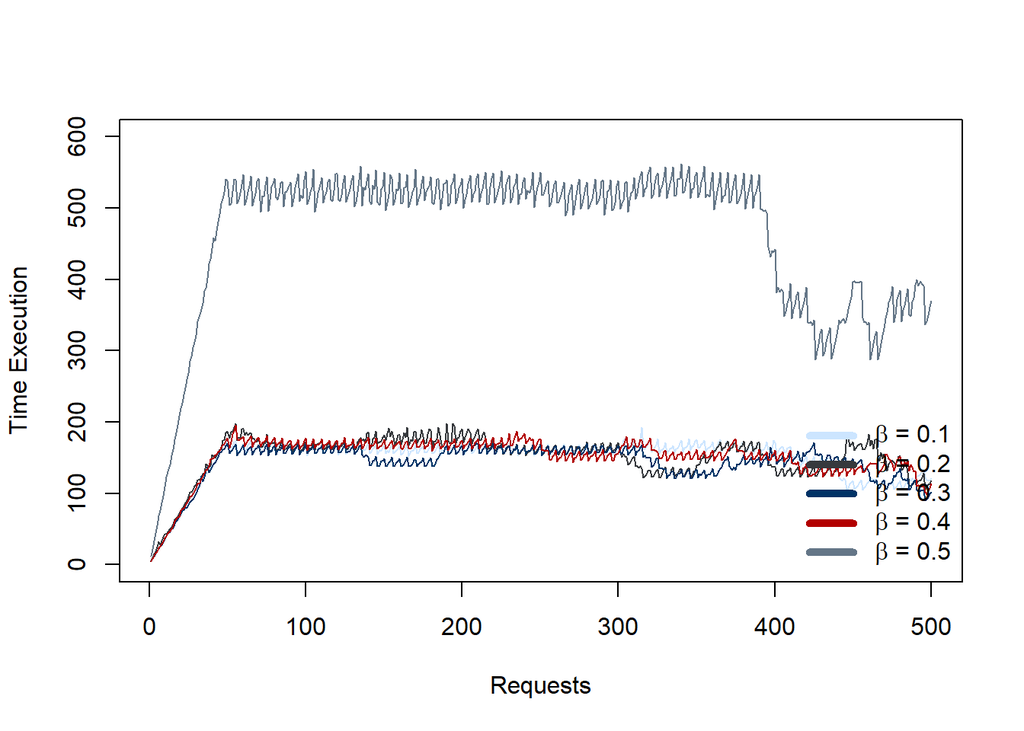

### Taxa de requisições alocadas.

$\alpha : 0.1 =$ 93.8% - 469/500.

$\alpha : 0.2 =$ 92.6% - 463/500.

$\alpha : 0.3 =$ 90.8% - 454/500.

$\alpha : 0.4 =$ 90.8% - 454/500.

$\alpha : 0.5 =$ 91.4% - 457/500.

### Distribuição da Latência

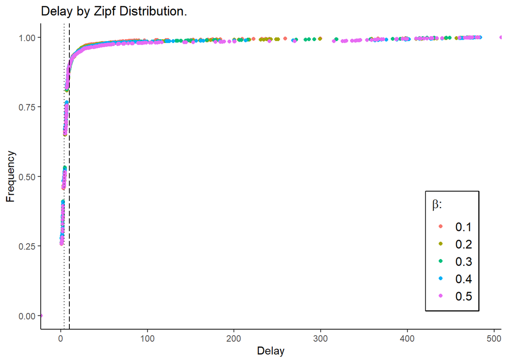

$\beta$: $0.1$

Em $46.24\%$ da amostra a latência das requisições são menores que $4$ milisegundos.

Em $89.52\%$ da amostra a latência das requisições são menores que $10$ milisegundos.

$\beta$: $0.2$

Em $46.88\%$ da amostra a latência das requisições são menores que $4$ milisegundos.

Em $88.52\%$ da amostra a latência das requisições são menores que $10$ milisegundos.

$\beta$: $0.3$

Em $48.76\%$ da amostra a latência das requisições são menores que $4$ milisegundos.

Em $88.56\%$ da amostra a latência das requisições são menores que $10$ milisegundos.

$\beta$: $0.4$

Em $47.42\%$ da amostra a latência das requisições são menores que $4$ milisegundos.

Em $89.55\%$ da amostra a latência das requisições são menores que $10$ milisegundos.

$\beta$: $0.5$

Em $46.65\%$ da amostra a latência das requisições são menores que $4$ milisegundos.

Em $89.3\%$ da amostra a latência das requisições são menores que $10$ milisegundos.

### Cache, Cloud e Storage.

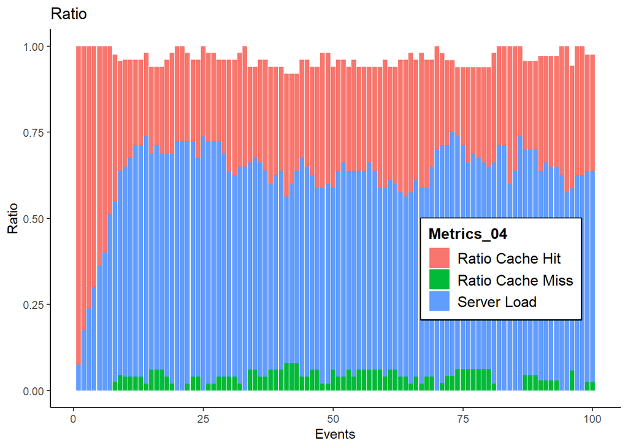

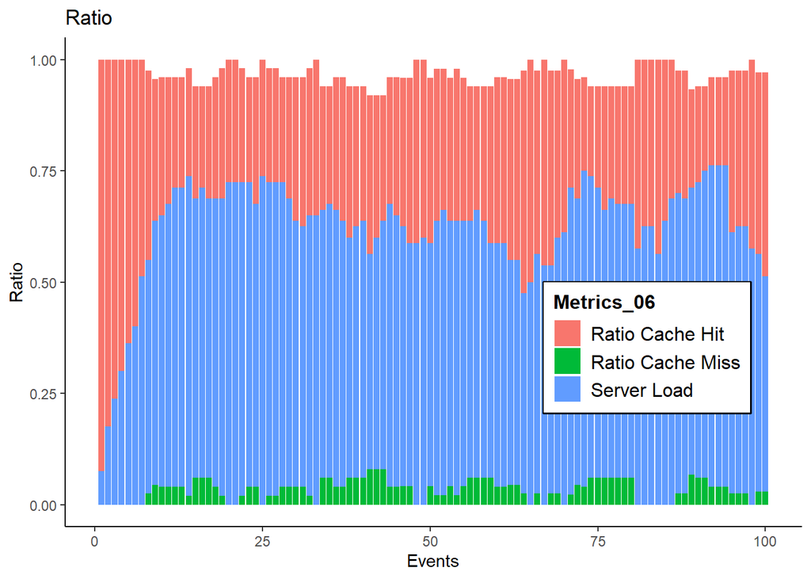

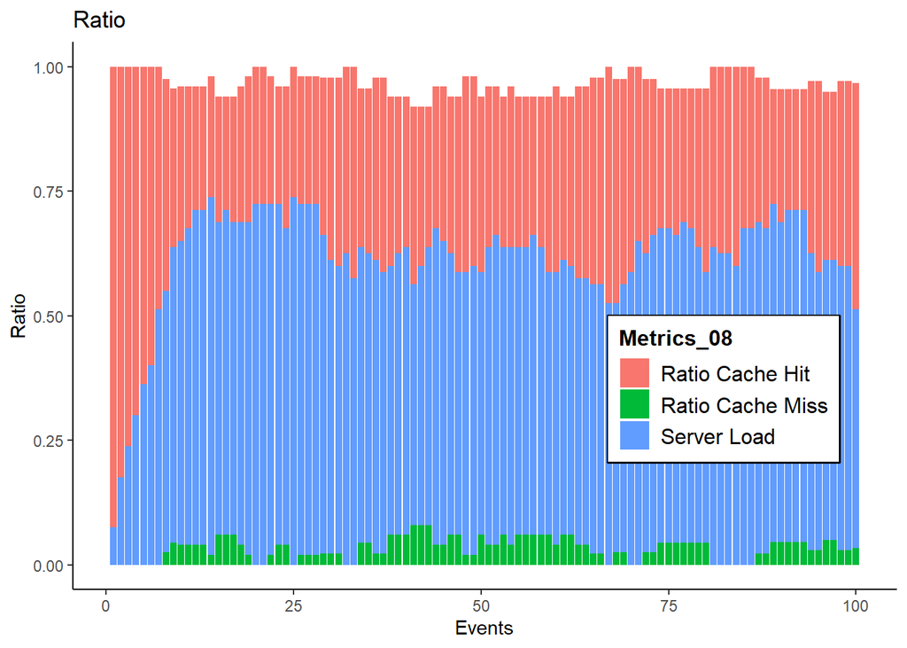

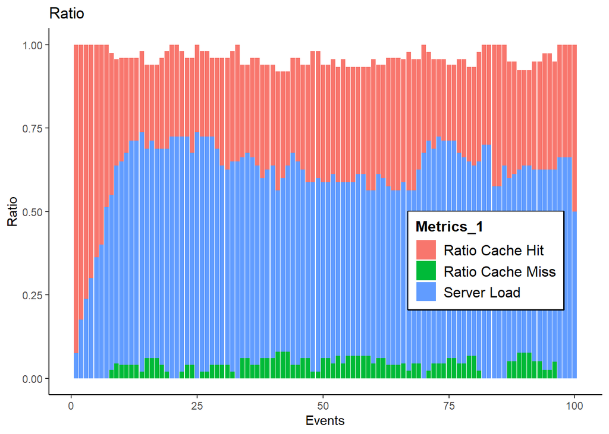

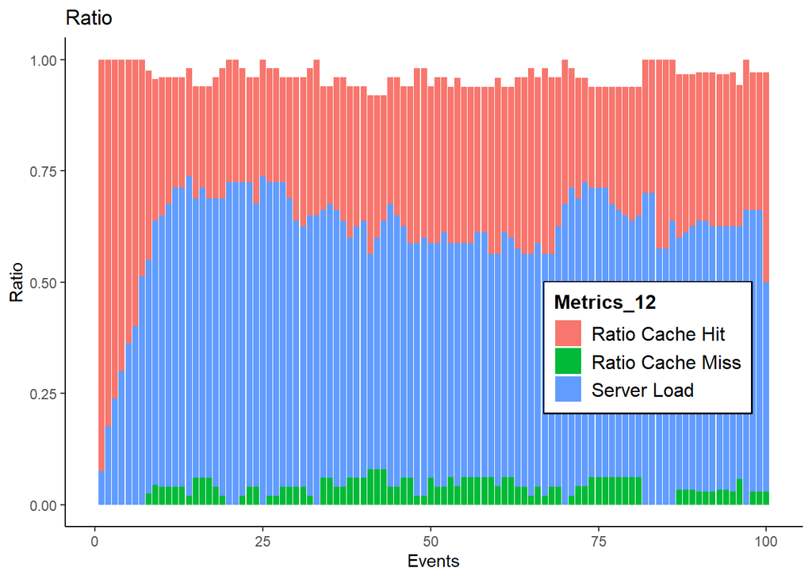

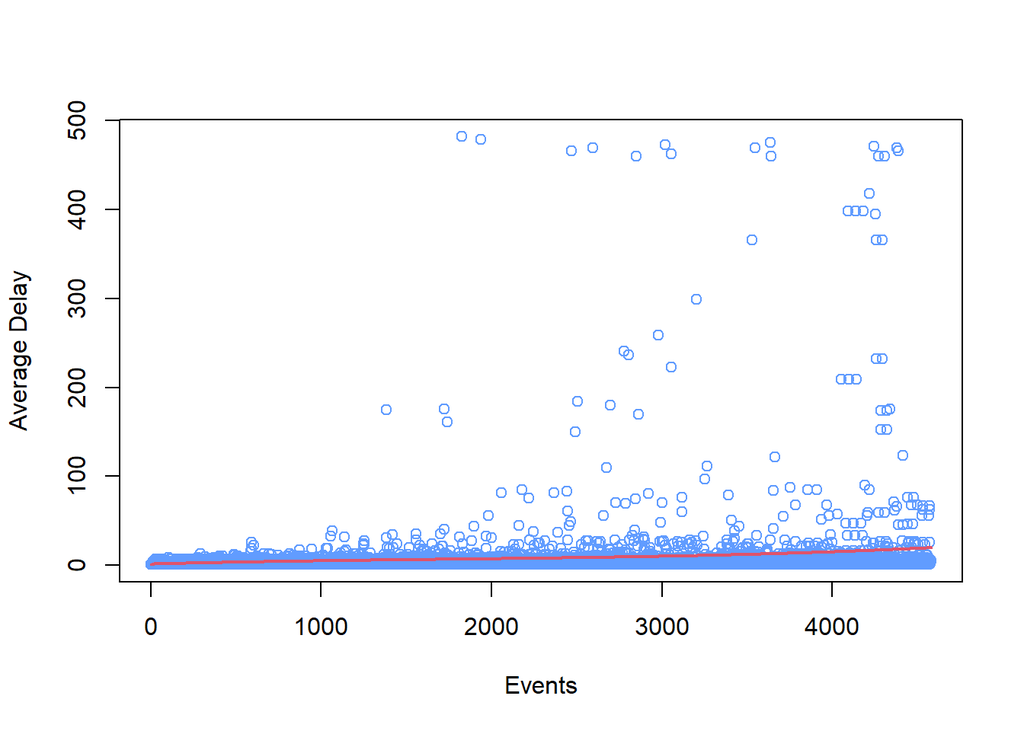

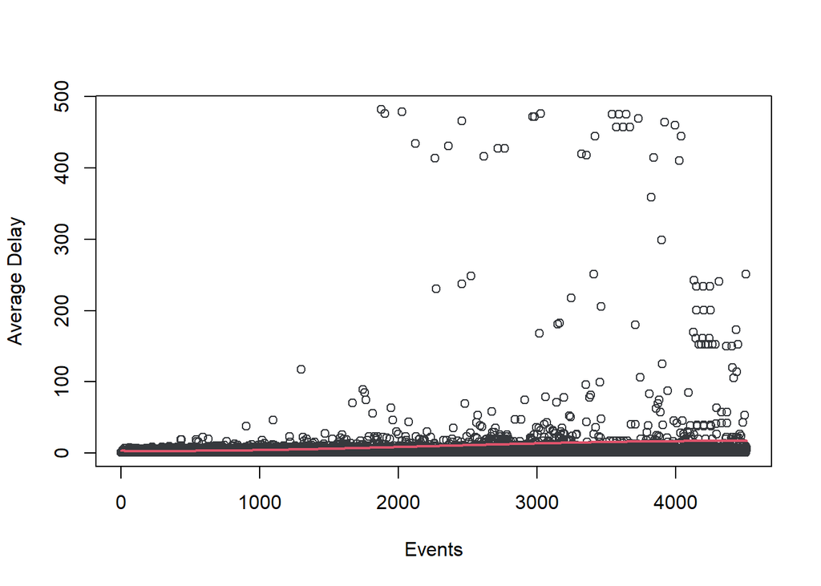

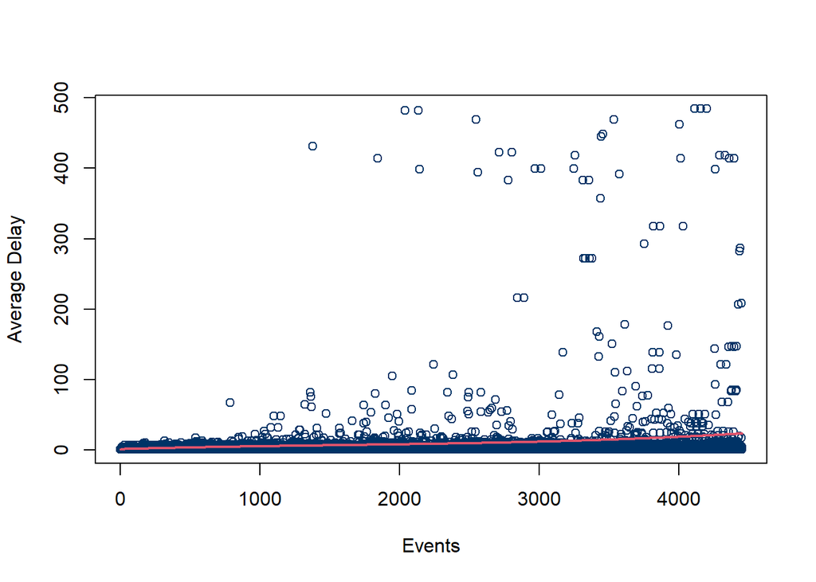

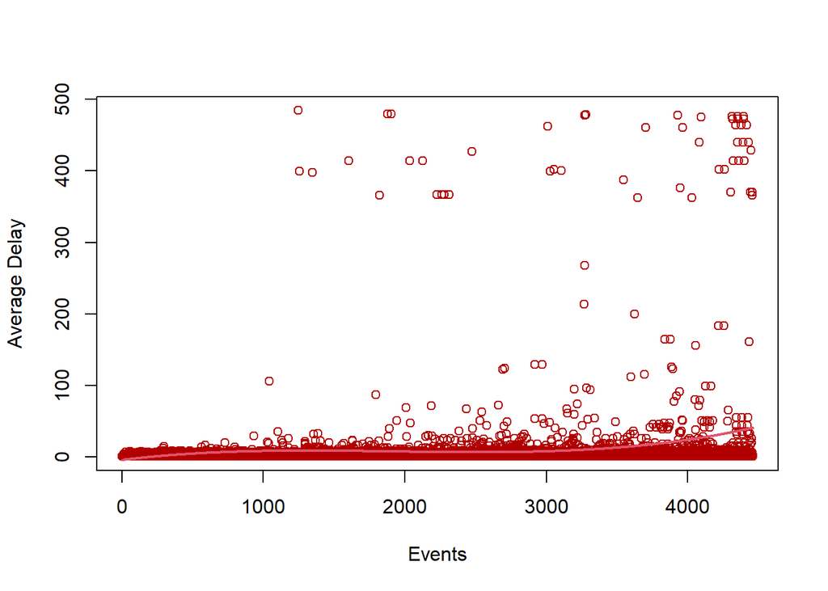

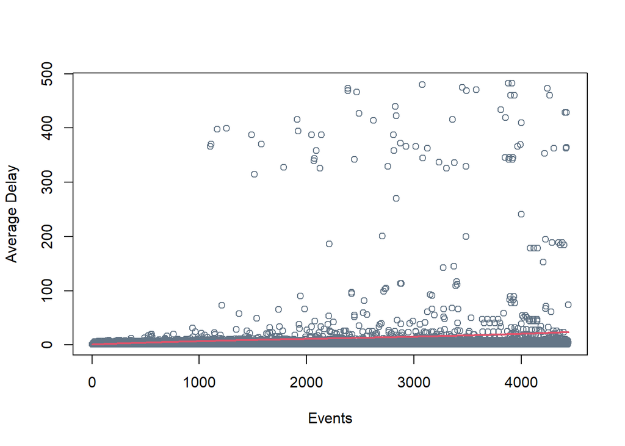

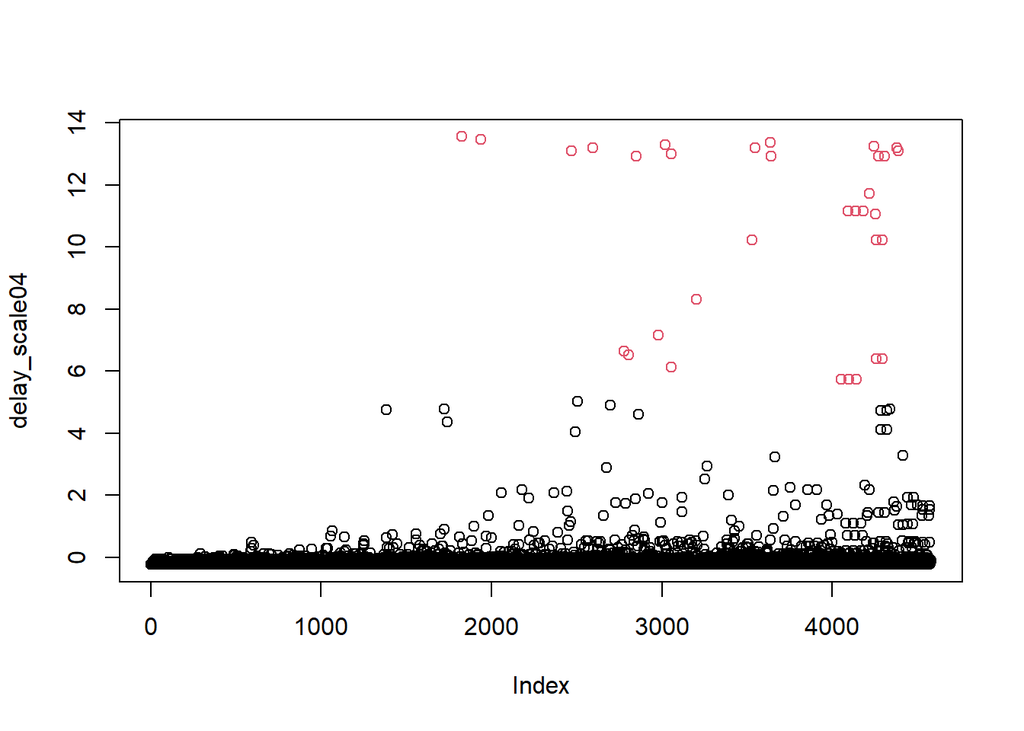

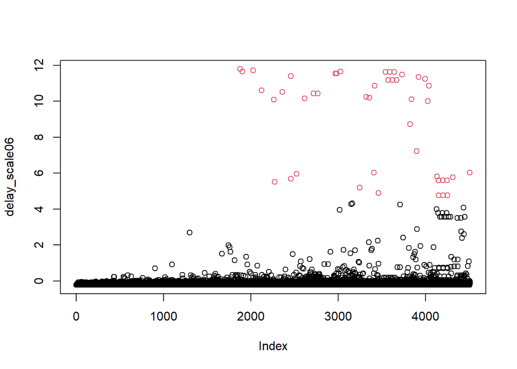

[29 more figures not shown]